# Project One: Multiple Regression, Qualitative Variables Interactions, Quadratic Regression

For Project One, you have been asked to create different regression models analyzing a housing data set. Before beginning work on the project, be sure to read through the Project One Guidelines and Rubric to understand what you need to do and how you will be graded on this assignment. Be sure to carefully review the Project One Summary Report template, which contains all of the questions that you will need to answer about the regression analyses you are performing.

For this project, you will be writing all the scripts yourself. You may reference the textbook and your previous work on the problem sets to help you write the scripts.

### Scenario

You are a data analyst working for a real estate company. You have access to a large set of historical data that you can use to analyze relationships between different attributes of a house (such as square footage or the number of bathrooms) and the house’s selling price. You have been asked to create different regression models to predict sale prices for houses based on critical variable factors. These regression models will help your company set better prices when listing a home for a client. Setting better prices will ensure that listings can be sold within a reasonable amount of time.

There are several variables in this data set, but you will be working with the following important variables:

| Variable | What does it represent? |
| --- | --- |
| price | Sale price of the home |
| bedrooms | Number of bedrooms |
| bathrooms | Number of bathrooms |
| sqft_living | Size of the living area in sqft |
| sqft_above | Size of the upper level in sqft |
| sqft_lot | Size of the lot in sqft |
| age | Age of the home |
| grade | Measure of craftsmanship and the quality of materials used to build the home |
| appliance_age | Average age of all appliances in the home |
| crime | Crime rate per 100,000 people |
| backyard | Home has a backyard (backyard=1) or not (backyard=0) |
| view | Home backs out to a lake (view=2), backs out to trees (view=1), or backs out to a road (view=0) |

# Prepare Your Data Set

In the following code block, you have been given the R code to prepare your data set.

Click the **Run** button on the toolbar to run this code.

```r
housing <- read.csv(file="housing.csv", header=TRUE, sep=",")

# converting appropriate variables to factors
housing <- within(housing, {
   view <- factor(view)
   backyard <- factor(backyard)
})

# number of columns
ncol(housing)

# number of rows
nrow(housing)
```

22

2692

# Model #1 - First Order Regression Model with Quantitative and Qualitative Variables

You have been asked to create a first order regression model for *price* as the response variable, and *sqft_living*, *grade*, *bathrooms*, and *view* as predictor variables. Before writing any code, review Section 3 of the Summary Report template to see the questions you will be answering about your first order multiple regression model.

Run your scripts to get the outputs of your regression analysis. Then use the outputs to answer the questions in your summary report.

**Note: Use the + (plus) button to add new code blocks, if needed.**

```r
print("head")
head(housing, 10)
```

```
[1] "head"
```

A data.frame: 10 × 22

| id <int> | price <int> | bedrooms <int> | bathrooms <dbl> | sqft_living <int> | sqft_lot <int> | floors <dbl> | backyard <fct> | view <fct> | condition <int> | ⋯ | sqft_basement <int> | yr_built <int> | yr_renovated <int> | renovated <int> | zipcode <int> | sqft_living15 <int> | sqft_lot15 <int> | age <int> | appliance_age <dbl> | crime <int> |
| --- | --- | --- | --- | --- | --- | --- | --- | --- | --- | --- | --- | --- | --- | --- | --- | --- | --- | --- | --- | --- |
| 1 | 325000 | 3 | 2.25 | 1570 | 43350 | 1.0 | 0 | 2 | 4 | ⋯ | 0 | 1967 | 0 | 0 | 98022 | 1570 | 220849 | 48 | 17.7 | 138 |
| 2 | 745000 | 5 | 3.00 | 2400 | 10126 | 2.0 | 0 | 2 | 3 | ⋯ | 0 | 1981 | 0 | 0 | 98126 | 2250 | 3946 | 34 | 3.2 | 101 |
| 3 | 571000 | 4 | 1.00 | 1350 | 4000 | 1.5 | 0 | 0 | 3 | ⋯ | 0 | 1930 | 0 | 0 | 98117 | 1520 | 4000 | 85 | 7.6 | 110 |
| 4 | 395000 | 2 | 2.00 | 1960 | 4018 | 1.0 | 0 | 0 | 5 | ⋯ | 980 | 1950 | 0 | 0 | 98108 | 1240 | 4641 | 65 | 13.0 | 118 |
| 5 | 449950 | 3 | 1.75 | 1470 | 7590 | 1.0 | 0 | 0 | 3 | ⋯ | 0 | 1988 | 0 | 0 | 98117 | 1700 | 5080 | 27 | 6.8 | 98 |
| 6 | 243000 | 3 | 1.75 | 1450 | 12125 | 1.0 | 0 | 0 | 4 | ⋯ | 0 | 1981 | 0 | 0 | 98001 | 1210 | 12125 | 34 | 14.1 | 209 |
| 7 | 219950 | 3 | 1.50 | 1070 | 6601 | 1.0 | 0 | 0 | 3 | ⋯ | 0 | 1985 | 0 | 0 | 98002 | 1030 | 6614 | 30 | 14.4 | 171 |
| 8 | 799000 | 5 | 2.75 | 2500 | 19783 | 1.0 | 1 | 2 | 4 | ⋯ | 0 | 1959 | 0 | 0 | 98005 | 1700 | 15375 | 56 | 5.1 | 96 |
| 9 | 207000 | 4 | 2.00 | 1690 | 7728 | 1.5 | 0 | 0 | 4 | ⋯ | 0 | 1967 | 0 | 0 | 98198 | 1480 | 8009 | 48 | 22.5 | 188 |
| 10 | 750000 | 4 | 2.75 | 2640 | 3750 | 2.0 | 0 | 0 | 5 | ⋯ | 800 | 1911 | 0 | 1 | 98117 | 1690 | 5000 | 104 | 5.8 | 40 |

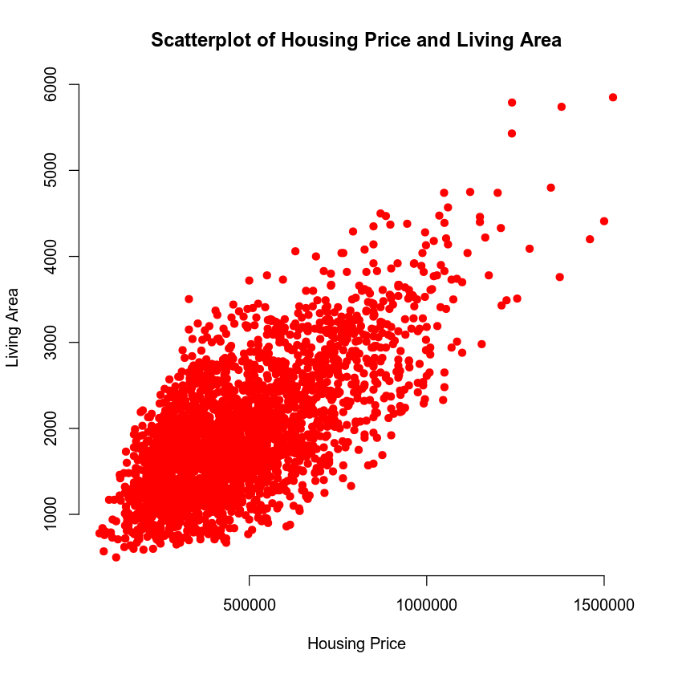

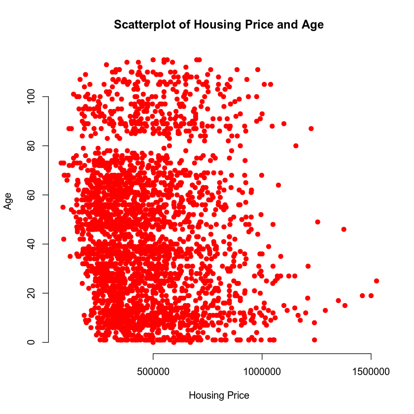

```r
#correlation analysis - price vs living area
plot(housing$price, housing$sqft_living,
     main = "Scatterplot of Housing Price and Living Area",
     xlab = "Housing Price", ylab = "Living Area",
     col="red",
     pch = 19, frame = FALSE)
#correlation analysis - price vs age of home
plot(housing$price, housing$age,
     main = "Scatterplot of Housing Price and Age",
     xlab = "Housing Price", ylab = "Age",
     col="red",
     pch = 19, frame = FALSE)
```

```r
#correlation matrix of price, square feet living area, age
myvars <- c("price", "sqft_living", "age")
housing_subset <- housing[myvars]
print("head")
head(housing_subset,6)

#print matrix
corr_matrix <- cor(housing_subset, method = "pearson")
round(corr_matrix,4)
```

```
[1] "head"
```

A data.frame: 6 × 3

| price <int> | sqft_living <int> | age <int> |
| --- | --- | --- |
| 325000 | 1570 | 48 |
| 745000 | 2400 | 34 |
| 571000 | 1350 | 85 |
| 395000 | 1960 | 65 |
| 449950 | 1470 | 27 |
| 243000 | 1450 | 34 |

A matrix: 3 × 3 of type dbl

|  | price | sqft_living | age |
| --- | --- | --- | --- |
| price | 1.0000 | 0.6895 | -0.0746 |
| sqft_living | 0.6895 | 1.0000 | -0.3547 |
| age | -0.0746 | -0.3547 | 1.0000 |

```r
#first order regression model price = sqft_living + grade + num_bath + view
model1 <- lm(price ~ sqft_living + grade + bathrooms + view, data = housing)
summary(model1)
```

```
Call:
lm(formula = price ~ sqft_living + grade + bathrooms + view,
    data = housing)

Residuals:
    Min      1Q  Median      3Q     Max
-378025  -91106   -8356   83217  383148

Coefficients:
              Estimate Std. Error t value Pr(>|t|)
(Intercept) -2.982e+05  2.118e+04 -14.083  < 2e-16 ***
sqft_living  9.384e+01  5.524e+00  16.986  < 2e-16 ***
grade        8.058e+04  3.574e+03  22.545  < 2e-16 ***
bathrooms   -2.182e+04  5.148e+03  -4.238 2.33e-05 ***
view1        1.657e+05  1.000e+04  16.559  < 2e-16 ***
view2        2.287e+05  1.134e+04  20.170  < 2e-16 ***
---
Signif. codes:  0 '***' 0.001 '**' 0.01 '*' 0.05 '.' 0.1 ' ' 1

Residual standard error: 125800 on 2686 degrees of freedom
Multiple R-squared:  0.6475,	Adjusted R-squared:  0.6469
F-statistic: 986.9 on 5 and 2686 DF,  p-value: < 2.2e-16
```

```r
#model prediction using view 2, 2150 sqft living, 7 grade and 3 bath
print("pred and conf for view 2, 2150 sqft living, 7 grade and 3 baths")
print("Prediction")
predict(model1, data.frame(view = "2", sqft_living = 2150, grade = 7, bathrooms = 3))
newdata <- data.frame(view = "2", sqft_living = 2150, grade = 7, bathrooms = 3)

print("prediction interval")
prediction_pred_int <- predict(model1, newdata, interval="predict", level=0.95)
round(prediction_pred_int,4)

print("confidence interval")
prediction_conf_int <- predict(model1, newdata, interval="confidence", level=0.95)
round(prediction_conf_int,4)

#model predictoin using view 0, 2150 sqft living, 7 grade and 3 bath
print("pred and conf for view 0, 2150 sqft living, 7 grade and 3 baths")
predict(model1, data.frame(view = "0", sqft_living = 2150, grade = 7, bathrooms = 3))
newdata <- data.frame(view = "0", sqft_living = 2150, grade = 7, bathrooms = 3)

print("prediction interval")
prediction_pred_int <- predict(model1, newdata, interval="predict", level=0.95)
round(prediction_pred_int,4)

print("confidence interval")
prediction_conf_int <- predict(model1, newdata, interval="confidence", level=0.95)
round(prediction_conf_int,4)
```

```
[1] "pred and conf for view 2, 2150 sqft living, 7 grade and 3 baths"
[1] "Prediction"
```

**1:** 630785.736977677

```
[1] "prediction interval"
```

A matrix: 1 × 3 of type dbl

| fit | lwr | upr |
| --- | --- | --- |
| 630785.7 | 382791.6 | 878779.9 |

```
[1] "confidence interval"
```

A matrix: 1 × 3 of type dbl

| fit | lwr | upr |
| --- | --- | --- |
| 630785.7 | 606031.7 | 655539.7 |

```
[1] "pred and conf for view 0, 2150 sqft living, 7 grade and 3 baths"
```

**1:** 402121.94558214

```
[1] "prediction interval"
```

A matrix: 1 × 3 of type dbl

| fit | lwr | upr |
| --- | --- | --- |
| 402121.9 | 155087.5 | 649156.4 |

```
[1] "confidence interval"
```

A matrix: 1 × 3 of type dbl

| fit | lwr | upr |
| --- | --- | --- |
| 402121.9 | 390387.1 | 413856.8 |

```r
#fitted
print("Fitted values model 1")
fitted_values1 <- fitted.values(model1)
head(fitted_values1, 20)

#residuals
print("Residual values model 1")
residuals1 <- residuals(model1)
head(residuals1, 20)
```

```
[1] "Fitted values model 1"
```

**1**

592724.252494169

**2**

734825.10189829

**3**

451270.528425711

**4**

406112.489057436

**5**

365586.53978485

**6**

363709.767575074

**7**

252926.353157903

**8**

749663.932814267

**9**

380776.064225384

**10**

453557.834588836

**11**

446287.744805463

**12**

351686.094973767

**13**

515194.478027102

**14**

375671.787882891

**15**

403885.023323088

**16**

469685.745134265

**17**

828191.52614057

**18**

947129.562405959

**19**

345354.391295285

**20**

343240.620029749

```
[1] "Residual values model 1"
```

**1**

-267724.252494169

**2**

10174.8981017104

**3**

119729.471574289

**4**

-11112.489057436

**5**

84363.46021515

**6**

-120709.767575074

**7**

-32976.3531579029

**8**

49336.0671857327

**9**

-173776.064225384

**10**

296442.165411164

**11**

-96287.7448054627

**12**

-79686.0949737667

**13**

-130244.478027102

**14**

-103671.787882891

**15**

-125885.023323088

**16**

70314.2548657352

**17**

-73191.52614057

**18**

-29129.562405959

**19**

65645.6087047152

**20**

-68240.6200297487

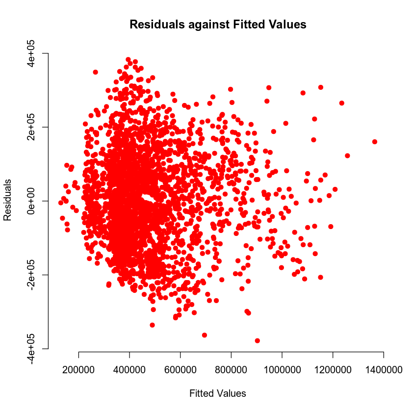

```r
#scatter plot residual against fitted
plot(fitted_values1, residuals1,
     main = "Residuals against Fitted Values",
     xlab = "Fitted Values", ylab = "Residuals",
     col="red",
     pch = 19, frame = FALSE)
```

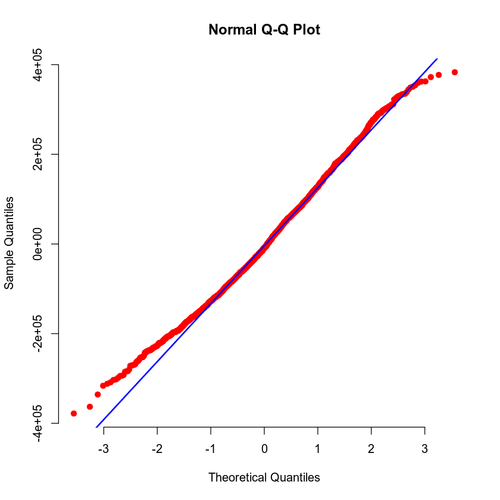

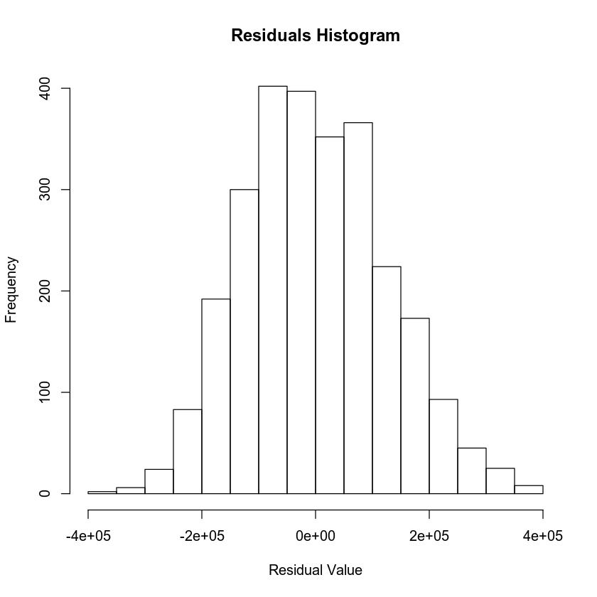

```r
#q-q plot
qqnorm(residuals1, pch = 19, col="red", frame = FALSE)
qqline(residuals1, col = "blue", lwd = 2)
hist(residuals1,
    main="Residuals Histogram",
    xlab="Residual Value")
```

# Model #2 - Complete Second Order Regression Model with Quantitative Variables

You have been asked to create a complete second order regression model for *price* as the response variable, and *appliance_age* and *crime* as predictor variables. Before writing any code, review Section 4 of the Summary Report template to see the questions you will be answering about your complete second order multiple regression model.

Run your scripts to get the outputs of your regression analysis. Then use the outputs to answer the questions in your summary report.

**Note: Use the + (plus) button to add new code blocks, if needed.**

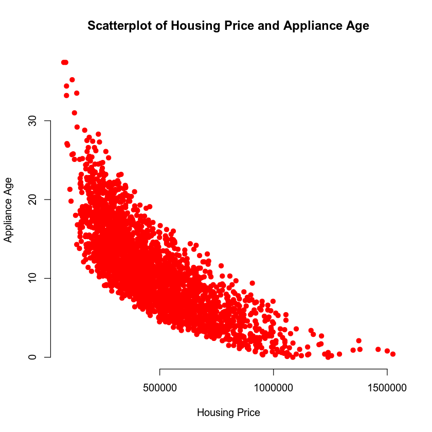

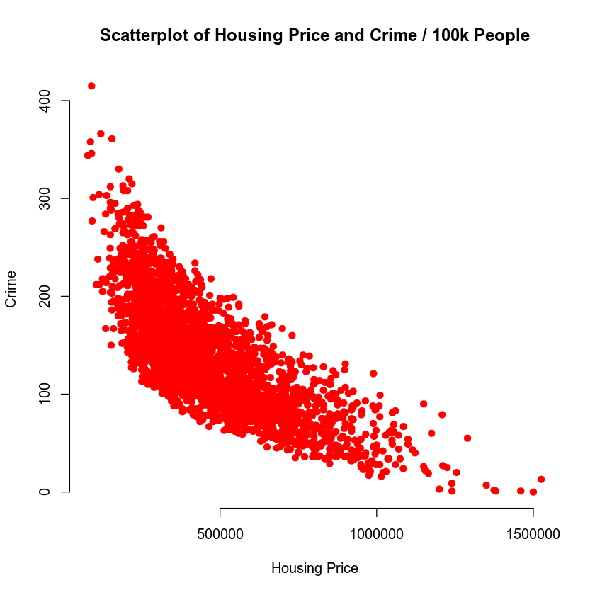

```r
#scatterplot price vs age of appliance
plot(housing$price, housing$appliance_age,
     main = "Scatterplot of Housing Price and Appliance Age",
     xlab = "Housing Price", ylab = "Appliance Age",
     col="red",
     pch = 19, frame = FALSE)
#scatterplot price vs crime rate / 100k people
plot(housing$price, housing$crime,
     main = "Scatterplot of Housing Price and Crime / 100k People",
     xlab = "Housing Price", ylab = "Crime",
     col="red",
     pch = 19, frame = FALSE)
```

```r
#second order regression price = age of appliances and crime rate
model2 <- lm(price ~ appliance_age + crime + appliance_age:crime + I(appliance_age^2) + I(crime^2), data = housing)
summary(model2)
```

```
Call:
lm(formula = price ~ appliance_age + crime + appliance_age:crime +
    I(appliance_age^2) + I(crime^2), data = housing)

Residuals:
    Min      1Q  Median      3Q     Max
-340502  -61196   -6241   57054  427449

Coefficients:
                      Estimate Std. Error t value Pr(>|t|)
(Intercept)          1.161e+06  9.116e+03 127.376   <2e-16 ***
appliance_age       -4.256e+04  1.375e+03 -30.951   <2e-16 ***
crime               -3.678e+03  1.481e+02 -24.827   <2e-16 ***
I(appliance_age^2)   8.330e+02  7.933e+01  10.501   <2e-16 ***
I(crime^2)           6.380e+00  7.265e-01   8.782   <2e-16 ***
appliance_age:crime  1.390e+01  1.298e+01   1.072    0.284
---
Signif. codes:  0 '***' 0.001 '**' 0.01 '*' 0.05 '.' 0.1 ' ' 1

Residual standard error: 92690 on 2686 degrees of freedom
Multiple R-squared:  0.8088,	Adjusted R-squared:  0.8084
F-statistic:  2272 on 5 and 2686 DF,  p-value: < 2.2e-16
```

```r
#model prediction for home one year appliance, crime rate 81.02 per 100k
print("pred and conf for home with 1 year old appliances and 81.02/100k crime rate")
newdata <- data.frame(appliance_age = 1, crime = 81.02)

print("prediction interval")
prediction_pred_int <- predict(model2, newdata, interval="predict", level=0.95)
round(prediction_pred_int,4)

print("confidence interval")
prediction_conf_int <- predict(model2, newdata, interval="confidence", level=0.95)
round(prediction_conf_int,4)

#model prediction for home 15 year old appliances and area with crime rate 200.50/100k
print("pred and conf for 15 year old appliances and 200.50 crime")
newdata <- data.frame(appliance_age = 15, crime = 200.50)

print("prediction interval")
prediction_pred_int <- predict(model2, newdata, interval="predict", level=0.95)
round(prediction_pred_int,4)

print("confidence interval")
prediction_conf_int <- predict(model2, newdata, interval="confidence", level=0.95)
round(prediction_conf_int,4)
```

```
[1] "pred and conf for home with 1 year old appliances and 81.02/100k crime rate"
[1] "prediction interval"
```

A matrix: 1 × 3 of type dbl

| fit | lwr | upr |
| --- | --- | --- |
| 864423.4 | 682264 | 1046583 |

```
[1] "confidence interval"
```

A matrix: 1 × 3 of type dbl

| fit | lwr | upr |
| --- | --- | --- |
| 864423.4 | 852131.8 | 876714.9 |

```
[1] "pred and conf for 15 year old appliances and 200.50 crime"
[1] "prediction interval"
```

A matrix: 1 × 3 of type dbl

| fit | lwr | upr |
| --- | --- | --- |
| 271051.6 | 89201.59 | 452901.6 |

```
[1] "confidence interval"
```

A matrix: 1 × 3 of type dbl

| fit | lwr | upr |
| --- | --- | --- |
| 271051.6 | 264848.1 | 277255.1 |

```r
#fitted
print("Fitted values model 2")
fitted_values2 <- fitted.values(model2)
head(fitted_values2, 20)

#residuals
print("Residual values model 2")
residuals2 <- residuals(model2)
head(residuals2, 20)
```

```
[1] "Fitted values model 2"
```

**1**

316695.530514426

**2**

731576.537613216

**3**

570036.614230382

**4**

424790.005257755

**5**

620337.456043773

**6**

277646.238069411

**7**

312881.154499544

**8**

678262.239741813

**9**

218111.164598272

**10**

808595.054217367

**11**

317105.027711281

**12**

346536.750848484

**13**

413459.341990428

**14**

214119.979121698

**15**

373503.464165386

**16**

464656.40730685

**17**

650628.36858935

**18**

799004.005093827

**19**

430814.764718544

**20**

337303.480086231

```
[1] "Residual values model 2"
```

**1**

8304.46948557354

**2**

13423.4623867836

**3**

963.38576961818

**4**

-29790.0052577546

**5**

-170387.456043773

**6**

-34646.2380694107

**7**

-92931.1544995438

**8**

120737.760258187

**9**

-11111.1645982721

**10**

-58595.0542173673

**11**

32894.9722887186

**12**

-74536.7508484836

**13**

-28509.3419904284

**14**

57880.0208783024

**15**

-95503.4641653865

**16**

75343.5926931499

**17**

104371.631410649

**18**

118995.994906173

**19**

-19814.7647185441

**20**

-62303.4800862315

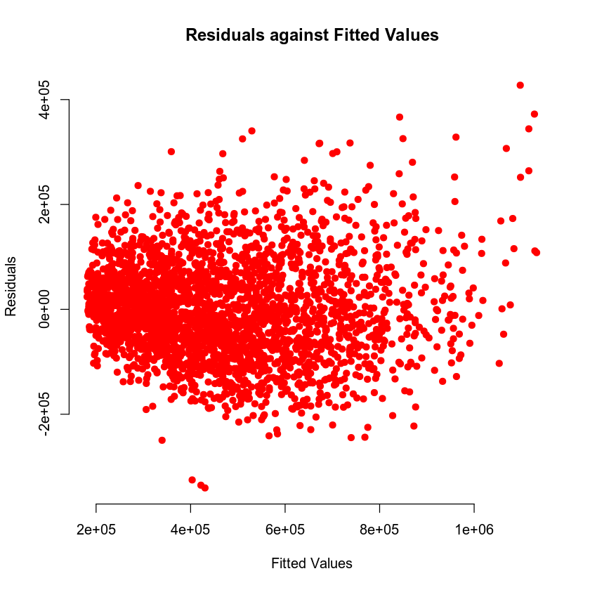

```r
#scatter plot residual against fitted
plot(fitted_values2, residuals2,
     main = "Residuals against Fitted Values",
     xlab = "Fitted Values", ylab = "Residuals",
     col="red",
     pch = 19, frame = FALSE)
```

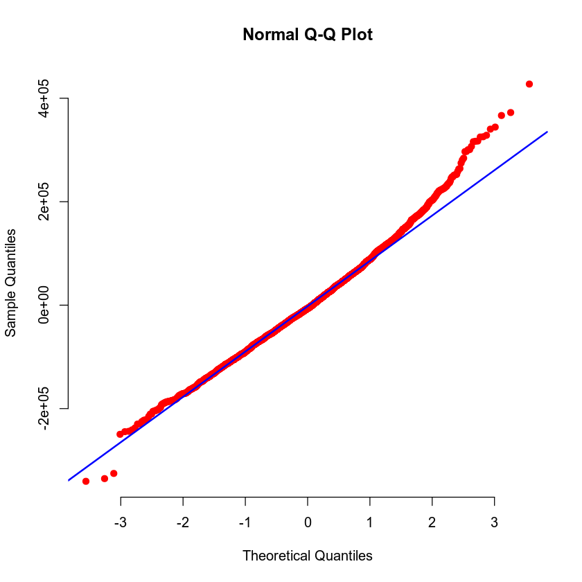

[figure not shown]

```r
#q-q plot
qqnorm(residuals2, pch = 19, col="red", frame = FALSE)
qqline(residuals2, col = "blue", lwd = 2)
hist(residuals1,
    main="Residuals Histogram",
    xlab="Residual Value")
```

# Nested Models F-Test

You have been asked to create a reduced model and compare it with the complete second order model (Model #2 above). Before writing any code, review Section 5 of the Summary Report template to see the questions you will need to answer.

Run your scripts to get the outputs of your regression analysis. Then use the outputs to answer the questions in your summary report.

**Note: Use the + (plus) button to add new code blocks, if needed.**

```r
model3 <- lm(price ~ appliance_age + crime + appliance_age:crime, data = housing)
summary(model3)
```

```
Call:
lm(formula = price ~ appliance_age + crime + appliance_age:crime,
    data = housing)

Residuals:
    Min      1Q  Median      3Q     Max
-336702  -63621   -4269   58742  439941

Coefficients:
                      Estimate Std. Error t value Pr(>|t|)
(Intercept)          1.145e+06  8.792e+03  130.27   <2e-16 ***
appliance_age       -4.159e+04  8.377e+02  -49.65   <2e-16 ***
crime               -3.418e+03  7.097e+01  -48.17   <2e-16 ***
appliance_age:crime  1.510e+02  4.775e+00   31.63   <2e-16 ***
---
Signif. codes:  0 '***' 0.001 '**' 0.01 '*' 0.05 '.' 0.1 ' ' 1

Residual standard error: 94880 on 2688 degrees of freedom
Multiple R-squared:  0.7995,	Adjusted R-squared:  0.7993
F-statistic:  3573 on 3 and 2688 DF,  p-value: < 2.2e-16
```

```r
anova(model2, model3)
```

A anova: 2 × 6

| Res.Df <dbl> | RSS <dbl> | Df <dbl> | Sum of Sq <dbl> | F <dbl> | Pr(>F) <dbl> |
| --- | --- | --- | --- | --- | --- |
| 2686 | 2.307487e+13 | NA | NA | NA | NA |
| 2688 | 2.419614e+13 | -2 | -1.121271e+12 | 65.26001 | 2.113594e-28 |

## End of Project One Jupyter Notebook

The HTML output can be downloaded by clicking **File**, then **Download as**, then **HTML**. Be sure to answer all of the questions in the Summary Report template for Project One, and to include your completed Jupyter Notebook scripts as part of your submission.